# Assignment 1 individual

```python
import pandas as pd
import seaborn as sns
import matplotlib.pyplot as plt
import numpy as np
```

```python
#read in data and display the head
data = pd.read_csv('house_data.csv')
#clean the data from any N/A value.
data.dropna(subset = ['id','price','bedrooms','bathrooms','sqm_living','sqm_lot','waterfront'], how = 'all')
data.head()
```

|  | id | price | bedrooms | bathrooms | sqm_living | sqm_lot | waterfront |
| --- | --- | --- | --- | --- | --- | --- | --- |
| 0 | 1 | 221900 | 3 | 1.00 | 109.624675 | 524.897807 | 0 |
| 1 | 2 | 538000 | 3 | 2.25 | 238.758826 | 672.798216 | 0 |
| 2 | 3 | 180000 | 2 | 1.00 | 71.534745 | 929.022668 | 0 |
| 3 | 4 | 604000 | 4 | 3.00 | 182.088443 | 464.511334 | 0 |
| 4 | 5 | 510000 | 3 | 2.00 | 156.075808 | 750.650316 | 0 |

I remove any N/A value in the data, but the data doesn't have any N/A value, since the number of rows of the data are the same after removing all the N/A value.

```
(21613, 21450, 163)
```

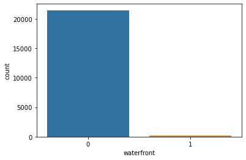

```python
ax = sns.countplot(x="waterfront", data=data)
data['waterfront'].count(), data.loc[data['waterfront']==0, 'price'].count(), data.loc[data['waterfront']==1, 'price'].count()
```

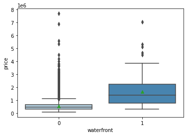

```python
ax = sns.boxplot(x='waterfront',y='price', data=data, palette='Blues', showmeans=True)
```

```python
data.loc[data['waterfront']==1, 'price'].describe().round(2)
```

```
count        163.00
mean     1661876.02
std      1120371.73
min       285000.00
25%       760000.00
50%      1400000.00
75%      2215000.00
max      7062500.00
Name: price, dtype: float64
```

```python
data.loc[data['waterfront']==0, 'price'].describe().round(2)
```

```
count      21450.00
mean      531563.60
std       341599.59
min        75000.00
25%       320000.00
50%       450000.00
75%       639897.00
max      7700000.00
Name: price, dtype: float64
```

```python
from scipy import stats
stats.describe(data.loc[data['waterfront']==1, 'price'])
```

```
DescribeResult(nobs=163, minmax=(285000, 7062500), mean=1661876.0245398772, variance=1255232816099.802, skewness=1.4427023109648562, kurtosis=3.127041653743727)
```

```python
stats.describe(data.loc[data['waterfront']==0, 'price'])
```

```
DescribeResult(nobs=21450, minmax=(75000, 7700000), mean=531563.5998135199, variance=116690279653.07115, skewness=3.654989000312272, kurtosis=31.377220837393942)
```

```python
meandif = 1661876.0245398772-531563.5998135199
mediandif = 1400000.00-450000.00
meandif,mediandif
```

```
(1130312.4247263572, 950000.0)
```

The difference between the price of a house in waterfront and house not located in waterfront is significant based on their mean and median difference which show house located in waterfront has higher mean price about \$1130312 higher in average compared to house not located in waterfront. While the median price difference between them are \\$950000. Both house located in waterfront. Both waterfront house data and non waterfront house has fat\heavy tail since their kurtosis both are positive, but house not located in waterfront has larger kurtosis compare to house located in waterfront.

```python
w_price = data.loc[data['waterfront']==1, 'price']
nw_price = data.loc[data['waterfront']==0, 'price']
stats.ttest_ind(w_price,nw_price, equal_var = False)
```

```
Ttest_indResult(statistic=12.875876891278113, pvalue=1.3791122647490577e-26)
```

```python
def confidence_interval_welch(xbar1, var1, n1, xbar2, var2, n2, alpha):
    mean = xbar1 - xbar2
    std_mean = np.sqrt(var1 / n1 + var2 / n2)

    p1 = (var1 / n1 + var2 / n2) ** 2
    p2 = ((var1 / n1) ** 2 / (n1 - 1)) + ((var2 / n2) ** 2 / (n2 - 1))
    dof = p1 / p2

    tcrit = stats.t.ppf(1 - alpha / 2., dof)
    lower = mean - tcrit * std_mean
    upper = mean + tcrit * std_mean
    return lower, upper, dof

# this function computes the Welch two-sample t-test
confidence_interval_welch(1661876.0245398772,1255232816099.802,163,531563.5998135199,116690279653.07115,21450,0.05)
```

```
(956963.2928260339, 1303661.5566266805, 162.22896438139523)
```

The hypotheses are:

$H_0:$ the two group means are equal: $\mu_{\text{Waterfront}} = \mu_{\text{NoWaterfront}}$.

$H_1:$ the two group means are not equal: $\mu_{\text{Waterfront}} \neq \mu_{\text{Nowaterfront}}$.

$\alpha=0.05$ as standard.

The test stat is $t = 12.88$, which has a t distribution with approximately 162 degrees of freedom, if the null of equality of means is, and the assumptions are also, true. The chance that the resulting t value would be as high or higher than $12.88$ in absolute value is very close to 0, i.e. here the p-val is $P(|t_{162} \geq 12.88) = 1.38 \times 10^{-26}$. This is $< 0.05$, so I reject the null and conclude that the two group means are significantly different to each other. In other words, there is a significant relationship between price and house located in waterfront.

The test assumed that the data are iid in each group, the two groups are independent of each other and the 4th moment of the price in each group is finite. The first and second assumption, the price of the house simply relies on waterfront or non waterfront, there are no other features that effect the price of the house (size of the house or house location), although this assumption has not been proven yet. The 4th moment assumption will be satisfied if price is a bounded variable. Clearly it is bounded below by \$0; further, since number of waterfront houses and non waterfront houses are finite and each prices tag of the house are finite, I can regard price as implicitly bounded via these aspects, but the outlier is not "rare" for both two groups of data so the 4th moment assumption are not quiet satissfied in here.

In summary, T-test is right only when the outlier of both two groups are "rare" and there is no other feature that effect the house price.

```python
from scipy.stats import median_test
median_test(w_price,nw_price,ties = 'ignore')
```

```
(120.41847933885634,
 5.122929482842407e-28,
 450000.0,
 array([[  152, 10597],
        [   11, 10681]], dtype=int64))
```

The hypotheses are:

$H_0: \mbox{median}_{Waterfall} = \mbox{median}_{NoWaterfall}$ vs

$H_1: \mbox{median}_{Waterfall} \neq \mbox{median}_{NoWaterfall}$.

I choose $\alpha = 0.05$ as standard.

The test statistic is $120.41847933885634$, which has a $\chi^2_1$ $(r-1)(c-1) = 1 \times 1 = 1$ distribution. If The contingency table presented as follows:

| Waterfall vs No Waterfall | Waterfall | No Waterfall | Total |
| --- | --- | --- | --- |
| Above median |  |  |  |
| 0 | 152 | 10597 | 10749 |
| (expected) | 82 | 10667 |  |
| 1 | 11 | 10681 | 10692 |
| (expected) | 81 | 10611 |  |
| Total | 163 | 21278 | 21441 |

The p-value is $P(\chi^2_1 > 120.41847933885634) =$ $5.122929482842407 \times 10^{-28}$. This is $< 0.05$, thus I reject null hypothesis. I conclude that there is significant (median) waterfall effect to the price of the property.

The assumption made are:

I assume both two group 'waterfront' and 'non waterfront' are independent group to each other.

Each cell in contigency table has expected value at least 5; the lowest is 81 e.g the first expected value is calculated by 163 * 10749/21441.

data are i.i.d in each group, house price are independent between each house and other house.

data are at least on the ordinal scale: Price is a ratio variable, so this satisfied.

```python
from scipy.stats import mannwhitneyu
mannwhitneyu(w_price,nw_price,alternative='two-sided')
```

```
MannwhitneyuResult(statistic=3090831.0, pvalue=3.2430420782356034e-64)
```

$H_0:$ waterfront house price has the same distribution as the non waterfront house price: $P(Y_1 > Y_2) = 0.5$; vs

I choose $\alpha = 0.05$ as standard.

The assumptions made are:

I assume both two group 'waterfront' and 'non waterfront' are independent group to each other.

data are i.i.d. in each group, house price are independent between each house and other house.

each group's sample size is large enough for the CLT to work. Sample sizes of 163 and 21450 and easily high enough here.

data are at least on the ordinal scale: price is a ratio variable, so this is satisfied.

Based on the lecture slide, T-test has the highest power when all of the assumptions are satisfied. while Mann-whitney U test has higher power than T-test if only T-test assumption are not well satisfied, in other hand it marginally lower power, Median test is the strongest if assumption from both of the test mentioned before are not satissfied. In my case, Man-Whitney U test will be the test that i believe the most, since it has the highest power compared to Median test and T-test that the assumption are not fulfilled.

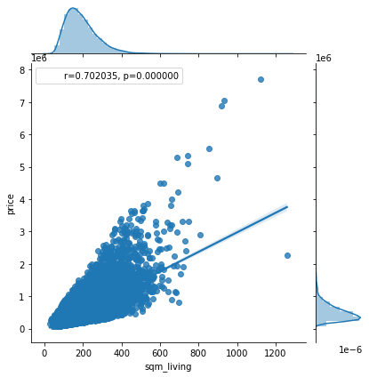

```python
graph = sns.jointplot(x=data['sqm_living'], y=data['price'], kind="reg")
r, p = stats.pearsonr(data['sqm_living'], data['price'])
phantom, = graph.ax_joint.plot([], [], linestyle="", alpha=0)
graph.ax_joint.legend([phantom],['r={:f}, p={:f}'.format(r,p)])
#plt.show()
```

I try to put the data in log format to see whether the data fit better or give larger pearsonr coefficient, with the logged format or the original format

```python
data['price'] = np.log(data['price'])
data['sqm_living'] = np.log(data['sqm_living'])
```

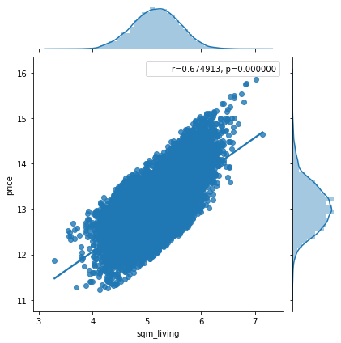

```python
graph = sns.jointplot(x=data['sqm_living'] , y=data['price'], kind="reg")
r, p = stats.pearsonr(data['sqm_living'],data['price'])
phantom, = graph.ax_joint.plot([], [], linestyle="", alpha=0)
graph.ax_joint.legend([phantom],['r={:f}, p={:f}'.format(r,p)])
#plt.show()
```

From the two graph, The original data and logged data indicates strong positive linear relationship between $sqm living$ and $price$, 0.702035 and 0.674913 but i decide to use the logged data for further observation since it show more linear correlation from the scatterplot.

```python
#OLS
import statsmodels.formula.api as smf    # this will fit regression models for us
OLS = smf.ols(formula='price ~ sqm_living', data=data).fit()
OLS.summary()
```

OLS Regression Results

| Dep. Variable: | price | R-squared: | 0.456 |
| --- | --- | --- | --- |
| Model: | OLS | Adj. R-squared: | 0.455 |
| Method: | Least Squares | F-statistic: | 1.808e+04 |
| Date: | Mon, 05 Apr 2021 | Prob (F-statistic): | 0.00 |
| Time: | 22:26:11 | Log-Likelihood: | -10240. |
| No. Observations: | 21613 | AIC: | 2.048e+04 |
| Df Residuals: | 21611 | BIC: | 2.050e+04 |
| Df Model: | 1 |  |  |
| Covariance Type: | nonrobust |  |  |

|  | coef | std err | t | P>\|t\| | [0.025 | 0.975] |
| --- | --- | --- | --- | --- | --- | --- |
| Intercept | 8.7183 | 0.032 | 269.846 | 0.000 | 8.655 | 8.782 |
| sqm_living | 0.8368 | 0.006 | 134.459 | 0.000 | 0.825 | 0.849 |

| Omnibus: | 123.344 | Durbin-Watson: | 1.978 |
| --- | --- | --- | --- |
| Prob(Omnibus): | 0.000 | Jarque-Bera (JB): | 113.759 |
| Skew: | 0.142 | Prob(JB): | 1.98e-25 |
| Kurtosis: | 2.787 | Cond. No. | 65.8 |

Warnings:  
[1] Standard Errors assume that the covariance matrix of the errors is correctly specified.

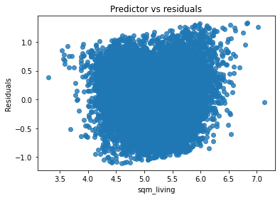

```python
fig, ax= plt.subplots()
sns.regplot(data['sqm_living'], OLS.resid, fit_reg=False)
ax.set_xlabel('sqm_living')
ax.set_ylabel('Residuals')
ax.set_title('Predictor vs residuals')
#plt.show()
```

The estimated relationship is: $\hat{Price}_t = 8.7183 + 0.8368living_{t-1}$; the parameter price (logged price) and sqm_living (logged sqm_living) have SE close to 0 which is 0.032 and 0.006 respectively. The effect of living area (logged sqm_living) increasing by 1% is that price (logged price) of the house tends to rise by 0.8368%, on average. The $R^{2}$ value is 0.456, which means that 45.6% goodness of fit to OLS model.

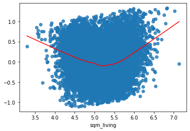

```python
import statsmodels.api as sm
lowess = sm.nonparametric.lowess
sns.regplot(data['sqm_living'], OLS.resid, fit_reg=False)
ax.set_xlabel('sqm_living')
ax.set_ylabel('Residuals')
ax.set_title('Predictor vs residuals')
z1 = lowess(OLS.resid, data['sqm_living'], frac=1./5)
plt.plot(z1[:,0],z1[:,1],'red')
```

Based on the residuals plot the pattern of the data are fairly random and i logged the data to increase the linearity of the data, which mean the data linearity of the data are satisfied. For the exogeneity assumption, the assumption is not quiet satisfied as the lowess line in the residual plot show a quadratic line instead of straight line across 0 in the Y-axis (residuals). Assumption about both of the data in each group are i.i.d are satisfied since both of the data has similar distribution and each data is independent from other data in the same group. Assumption about two return series have finite 4th moments, the data has positive kurtosis which mean it has fat tailed mean that the outlier in the data is not quiet "rare", so this assumption are weak. Assumption about homoskedascity. The residuals plot suggest that variance of sqm_living and price seems constant (residual plot look homoskedascity), so this assumption is okay.

```python
#LDA
mod = smf.quantreg('price ~ sqm_living', data=data)
LDA = mod.fit(q=.5)
LDA.summary()
```

QuantReg Regression Results

| Dep. Variable: | price | Pseudo R-squared: | 0.2386 |
| --- | --- | --- | --- |
| Model: | QuantReg | Bandwidth: | 0.07197 |
| Method: | Least Squares | Sparsity: | 1.043 |
| Date: | Mon, 05 Apr 2021 | No. Observations: | 21613 |
| Time: | 22:26:15 | Df Residuals: | 21611 |
|  |  | Df Model: | 1 |

|  | coef | std err | t | P>\|t\| | [0.025 | 0.975] |
| --- | --- | --- | --- | --- | --- | --- |
| Intercept | 8.7791 | 0.043 | 202.437 | 0.000 | 8.694 | 8.864 |
| sqm_living | 0.8275 | 0.008 | 99.062 | 0.000 | 0.811 | 0.844 |

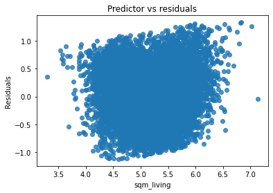

```python
fig, ax= plt.subplots()
sns.regplot(data['sqm_living'], LDA.resid, fit_reg=False)
ax.set_xlabel('sqm_living')
ax.set_ylabel('Residuals')
ax.set_title('Predictor vs residuals')
#plt.show()
```

The relationship is positive, with a 1% increase in sqm_living (logged sqm_living) associated with a median increase in the price (logged price) by 0.8275%. The intercept of 8.78%. SE (standard error) of the parameter price (logged price) and sqm_living (logged sqm_living) are both close to 0 (0.043 and 0.008 respectively).

Assumption about linearity and median , the data is linear based on the fairly random pattern in the residual and i logged the data to increase the linearity of the data, the plot suggest that (mean and median) residuals is 0. Assumption of each data group are i.i.d has been explained before in the OLS model, so this satissfied as well. Assumption of continuity density function are simply stated as true which need $p(Y|X)$ to estimate. Assumption 1st moment of Y exist and 2nd moment of X exist, First the outlier don't need to be "rare" (4th moment exist), The number and level of outlier should be considered as extreme to not satisfy this two assumption, so nothing strongly suggest these assumptions are not satsfied.

Based on the finding of the two model, The LDA model suit more with my finding since the data can not satissfied 4th moment assumption for the OLS model and the assumption of exogeneity is weak, In this case LDA model fit more.